# Alzheimer’s Disease Resarch Project

Abhinav Vedati, Chris Lippi

11/09/2020

## Introduction

Alzheimer’s Disease is one of the world’s most devastating and deadly diseases. Alzheimer’s Disease affects nearly [50 million people worldwide](https://www.alzheimers.net/resources/alzheimers-statistics/) and [more than 5 million people in the United States](https://www.alz.org/alzheimers-dementia/facts-figures#:~:text=More%20than%205%20million%20Americans%20of%20all%20ages%20have%20Alzheimer's,are%20age%2075%20or%20older.) Despite these devastating statistics, Alzheimer’s Disease is one of the least understood diseases. While progress has been made over the past several decades in finding cures and treatments for cancers and diseases such as measles, there has yet to be a single drug that improves the condition of or cures Alzheimer’s Disease (all simply slow the progression of the disease). Part of the reason why we have not yet found a cure for Alzheimer’s Disease is that we don’t understand the underlying causes of the disease very well. In this paper, we aim to take the first steps towards establishing causality in the context of Alzheimer’s Disease, by finding variables that are correlated with clinical dementia rating (a 5 point scale used to characterize the development of dementias such as Alzheimer’s Disease within a patient) and Mini-Mental State Exam scores (the Mini-Mental State Exam is a quiz given to dementia patients; it is graded on a scale from 0 to 30 points, where a higher score indicates milder dementia). we will be using a dataset provided by [Kaggle and the Open Access Series of Imaging Studies (OASIS)](https://www.kaggle.com/jboysen/mri-and-alzheimers)

## Part 1: Finding correlations

First, we loaded our dataset and inspected it using the names function. This allowed us to see the names of the columns that our dataset contains.

```r
dataFrame <- read.csv("oasis_cross-sectional.csv", header=TRUE, sep=",")
names(dataFrame)
```

```
##  [1] "ID"    "M.F"   "Hand"  "Age"   "Educ"  "SES"   "MMSE"  "CDR"   "eTIV"
## [10] "nWBV"  "ASF"   "Delay"
```

Next, we defined two functions, which will try to fit the data to a linear model and a logarithmic model, respectively. Both of these functions will return the r squared correlation coefficient for their models.

```r
plot_linear <- function(columns, name1, name2) {
  neededData = na.omit(columns)
  plot(neededData[,name1], neededData[,name2], xlab=name1, ylab=name2)
  model <- lm(neededData[,name2] ~ neededData[,name1])
  abline(model)
  summary(model)$r.squared
}

plot_logarithmic <- function(columns, name1, name2) {
  neededData = na.omit(columns)
  plot(neededData[,name1],
       log(neededData[,name2]),
       xlab=name1,
       ylab=paste("log(",name2,")", sep="")
       )
  model <- lm(log(neededData[,name2]) ~ neededData[,name1])
  abline(model)
  summary(model)$r.squared
}
```

We will now invididually graph patient estimated total intracranial volume (eTIV) and patient normalized whole brain volume (nWBV) against patient Mini–Mental State Examination (MMSE) scores. For both graphs, we will fit the data to a linear and a nonlinear model.

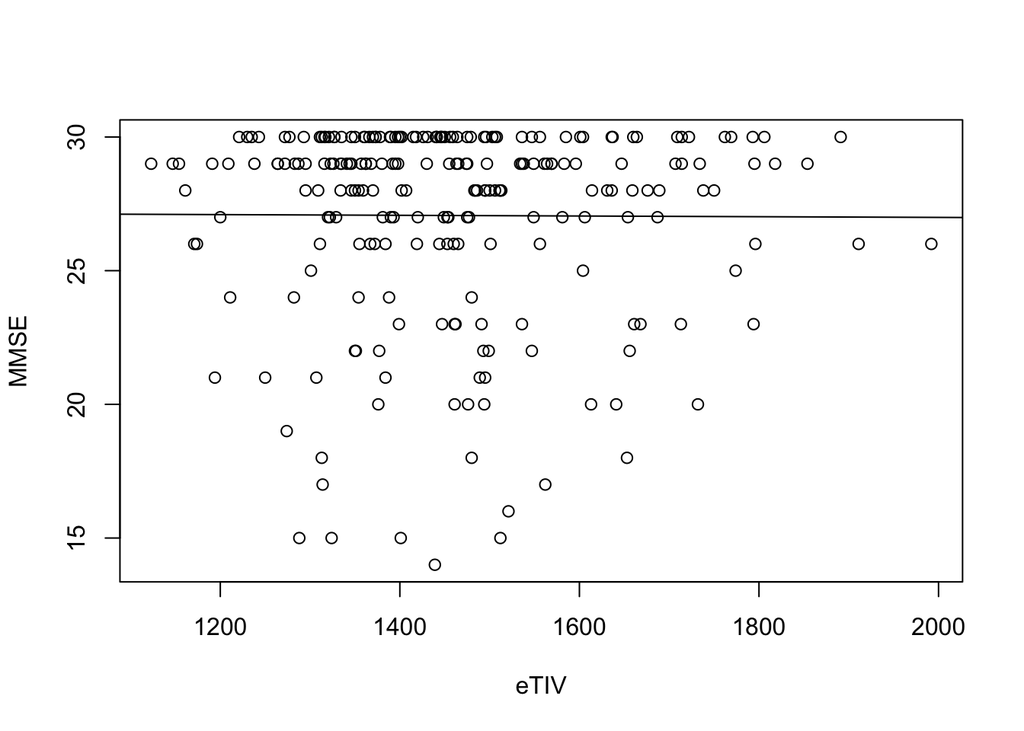

```r
R_squared_eTIV_MMSE_lin <- plot_linear(dataFrame[,c(7,9)], "eTIV", "MMSE")
```

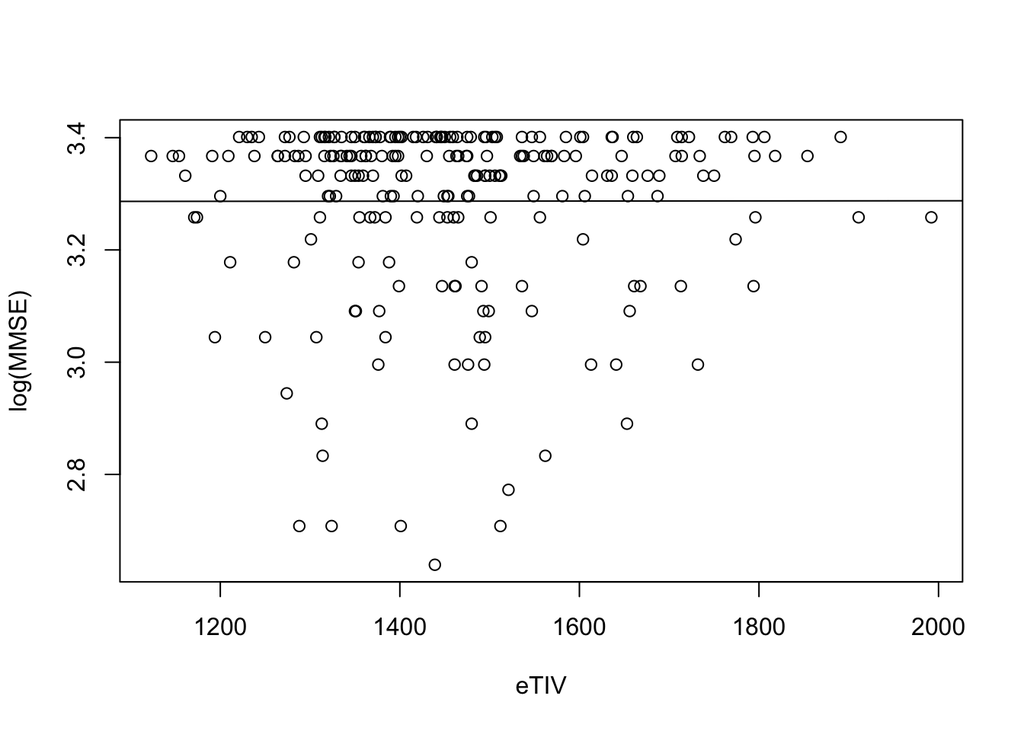

```r
R_squared_eTIV_MMSE_log <- plot_logarithmic(dataFrame[,c(7,9)], "eTIV", "MMSE")
```